# Prosper Loan Analysis

## Dataset Structure

The project centers on a dataset obtained from Prosper a lending platform in America. The dataset contains 113,937 loans with 81 variables on each loan observations. Such variables include Loan Status, Prosper Rating, Prosper Score, Employmetn STtaus, Borrower APR & Rate etc.

## Investigative Overview

As a practicing Credit Officer in a Microfinance Bank, I decided to understand the relationship between various variables in the dataet. I vhose variables such as Employment Status, Income Range, Term of Loan, Debt to Income Ratio and how those characteristics affected or the relationship with Borrower APR, Loan Status and Prosper Rating.

```python
#importing the nexcessary libraries
import numpy as np
import pandas as pd
import matplotlib.pyplot as plt
import seaborn as sns
import warnings
warnings.filterwarnings('ignore')

%matplotlib inline
```

```python
#loading the csv data into a dataframe named prosperloandf
prosperloandf = pd.read_csv('prosperLoanData.csv')
prosperloandf.head()
```

|  | ListingKey | ListingNumber | ListingCreationDate | CreditGrade | Term | LoanStatus | ClosedDate | BorrowerAPR | BorrowerRate | LenderYield | ... | LP_ServiceFees | LP_CollectionFees | LP_GrossPrincipalLoss | LP_NetPrincipalLoss | LP_NonPrincipalRecoverypayments | PercentFunded | Recommendations | InvestmentFromFriendsCount | InvestmentFromFriendsAmount | Investors |
| --- | --- | --- | --- | --- | --- | --- | --- | --- | --- | --- | --- | --- | --- | --- | --- | --- | --- | --- | --- | --- | --- |
| 0 | 1021339766868145413AB3B | 193129 | 2007-08-26 19:09:29.263000000 | C | 36 | Completed | 2009-08-14 00:00:00 | 0.16516 | 0.1580 | 0.1380 | ... | -133.18 | 0.0 | 0.0 | 0.0 | 0.0 | 1.0 | 0 | 0 | 0.0 | 258 |
| 1 | 10273602499503308B223C1 | 1209647 | 2014-02-27 08:28:07.900000000 | NaN | 36 | Current | NaN | 0.12016 | 0.0920 | 0.0820 | ... | 0.00 | 0.0 | 0.0 | 0.0 | 0.0 | 1.0 | 0 | 0 | 0.0 | 1 |
| 2 | 0EE9337825851032864889A | 81716 | 2007-01-05 15:00:47.090000000 | HR | 36 | Completed | 2009-12-17 00:00:00 | 0.28269 | 0.2750 | 0.2400 | ... | -24.20 | 0.0 | 0.0 | 0.0 | 0.0 | 1.0 | 0 | 0 | 0.0 | 41 |
| 3 | 0EF5356002482715299901A | 658116 | 2012-10-22 11:02:35.010000000 | NaN | 36 | Current | NaN | 0.12528 | 0.0974 | 0.0874 | ... | -108.01 | 0.0 | 0.0 | 0.0 | 0.0 | 1.0 | 0 | 0 | 0.0 | 158 |
| 4 | 0F023589499656230C5E3E2 | 909464 | 2013-09-14 18:38:39.097000000 | NaN | 36 | Current | NaN | 0.24614 | 0.2085 | 0.1985 | ... | -60.27 | 0.0 | 0.0 | 0.0 | 0.0 | 1.0 | 0 | 0 | 0.0 | 20 |

5 rows × 81 columns

```python
#because of the lengthy number of columns pandas didtn show all
#I had to use the set_option to be able to display all
pd.set_option("display.max_columns", len(prosperloandf.columns))
```

```python
#after going through all the columns i decided to work on just a few of the columns
cols = ['Term', 'LoanStatus', 'EstimatedEffectiveYield', 'BorrowerAPR', 'BorrowerRate', 'ProsperRating (Alpha)', 'ProsperScore', 'ListingCategory (numeric)', 'BorrowerState', 'Occupation', 'EmploymentStatus', 'CurrentDelinquencies', 'DebtToIncomeRatio', 'IncomeRange', 'LoanOriginalAmount', 'StatedMonthlyIncome', 'IncomeVerifiable', 'IsBorrowerHomeowner']
```

```python
#added the columns into a new dataframe that i will be using for my analysis
prosperloan = prosperloandf[cols]
```

```python
# found the rows that have null values
prosperloan.isna().sum()
```

```
Term                             0
LoanStatus                       0
EstimatedEffectiveYield      29084
BorrowerAPR                     25
BorrowerRate                     0
ProsperRating (Alpha)        29084
ProsperScore                 29084
ListingCategory (numeric)        0
BorrowerState                 5515
Occupation                    3588
EmploymentStatus              2255
CurrentDelinquencies           697
DebtToIncomeRatio             8554
IncomeRange                      0
LoanOriginalAmount               0
StatedMonthlyIncome              0
IncomeVerifiable                 0
IsBorrowerHomeowner              0
dtype: int64
```

```python
# here i decided to exclude columns fro Prosper Rating that were null from the datafra,e
prosperloan = prosperloan[prosperloan['ProsperRating (Alpha)'].notnull()]
```

```python
# i then checked the columns that still had null values
prosperloan.isna().sum()
```

```
Term                            0
LoanStatus                      0
EstimatedEffectiveYield         0
BorrowerAPR                     0
BorrowerRate                    0
ProsperRating (Alpha)           0
ProsperScore                    0
ListingCategory (numeric)       0
BorrowerState                   0
Occupation                   1333
EmploymentStatus                0
CurrentDelinquencies            0
DebtToIncomeRatio            7296
IncomeRange                     0
LoanOriginalAmount              0
StatedMonthlyIncome             0
IncomeVerifiable                0
IsBorrowerHomeowner             0
dtype: int64
```

```python
#i realised that since this particular column is occupation if it were null it would mean probably it was not filled or rather unkown
#i then decided to fill those null values with unknown so as not to disrupt the data
prosperloan.Occupation = prosperloan.Occupation.fillna('Unknown')
```

```python
#rechecked the columns still null
prosperloan.isna().sum()
```

```
Term                            0
LoanStatus                      0
EstimatedEffectiveYield         0
BorrowerAPR                     0
BorrowerRate                    0
ProsperRating (Alpha)           0
ProsperScore                    0
ListingCategory (numeric)       0
BorrowerState                   0
Occupation                      0
EmploymentStatus                0
CurrentDelinquencies            0
DebtToIncomeRatio            7296
IncomeRange                     0
LoanOriginalAmount              0
StatedMonthlyIncome             0
IncomeVerifiable                0
IsBorrowerHomeowner             0
dtype: int64
```

```python
#for the DebtToIncoomeRatio it would be wise to use the mean values to substitute for those null rows
prosperloan.DebtToIncomeRatio = prosperloan.DebtToIncomeRatio.fillna(prosperloan.DebtToIncomeRatio.mean())
```

```python
prosperloan.isna().sum()
```

```
Term                         0
LoanStatus                   0
EstimatedEffectiveYield      0
BorrowerAPR                  0
BorrowerRate                 0
ProsperRating (Alpha)        0
ProsperScore                 0
ListingCategory (numeric)    0
BorrowerState                0
Occupation                   0
EmploymentStatus             0
CurrentDelinquencies         0
DebtToIncomeRatio            0
IncomeRange                  0
LoanOriginalAmount           0
StatedMonthlyIncome          0
IncomeVerifiable             0
IsBorrowerHomeowner          0
dtype: int64
```

```python
#looking at the data, there were some ordinal data columns which needed to be ranked
#here i loaded it as a dictionary and then loaded it back into the dataframe using a for loop
ordinal_datadict = {'ProsperRating (Alpha)': ['AA', 'A', 'B', 'C', 'D', 'E', 'HR'],
                    'LoanStatus': prosperloan.LoanStatus.value_counts().sort_index().index,
                    'EmploymentStatus': prosperloan.EmploymentStatus.value_counts().sort_index().index,
                    'IncomeRange': ['Not employed', '$0', '$1-24,999', '$25,000-49,999', '$50,000-74,999', '$75,000-99,999', '$100,000+']}

for var in ordinal_datadict:
    ordered_var = pd.api.types.CategoricalDtype(ordered = True,
                                                categories = ordinal_datadict[var])
    prosperloan[var] = prosperloan[var].astype(ordered_var)
```

## UNIVARIATE EXPLORATION

### Distribution of Term

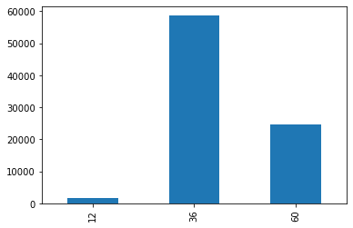

```python
#Term of Loans using matplotlib

prosperloan.Term.value_counts().sort_index().plot.bar()
plt.show()
```

### Loan Status

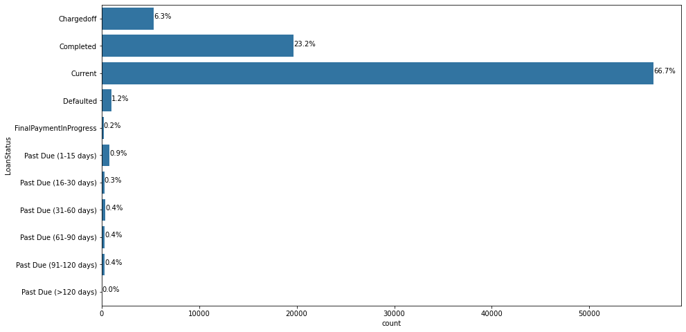

```python
#calculating the Loan Status in percentages so as to know status percentages
ax = plt.figure(figsize=(15, 8))
base_color = sns.color_palette()[0]
ax = sns.countplot(data=prosperloan, y='LoanStatus', color=base_color)
total = len(prosperloan.LoanStatus)
for p in ax.patches:
        percentage = '{:.1f}%'.format(100 * p.get_width()/total)
        x = p.get_x() + p.get_width() + 0.02
        y = p.get_y() + p.get_height()/2
        ax.annotate(percentage, (x, y));
```

## Distribution of Borrower APR

Borrower APR Distribution is also multi modal with various peaks at 0.17, 0.21 and at 0.36

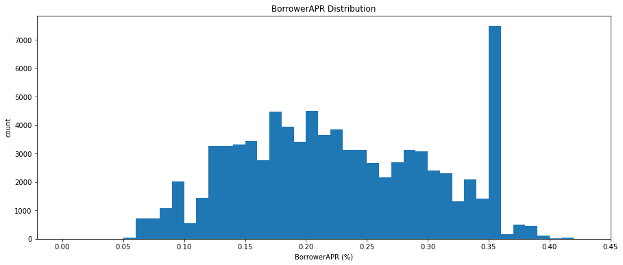

```python
plt.figure(figsize=(15,6))

bins = np.arange(0, prosperloan.BorrowerAPR.max(), 0.01)
plt.hist(prosperloan.BorrowerAPR, bins = bins)
plt.title('BorrowerAPR Distribution')
plt.xlabel('BorrowerAPR (%)')
plt.ylabel('count')
plt.xticks(np.arange(0, prosperloan.BorrowerAPR.max()+0.05, 0.05));
```

## Distribution of ProsperRating Alpha

Most loans were rated average or in the middle, neither high nor low Very few loans were give the highest rating of AA

```python
prosperloan['ProsperRating (Alpha)'].unique()
```

```
['A', 'D', 'B', 'E', 'C', 'AA', 'HR']
Categories (7, object): ['AA' < 'A' < 'B' < 'C' < 'D' < 'E' < 'HR']
```

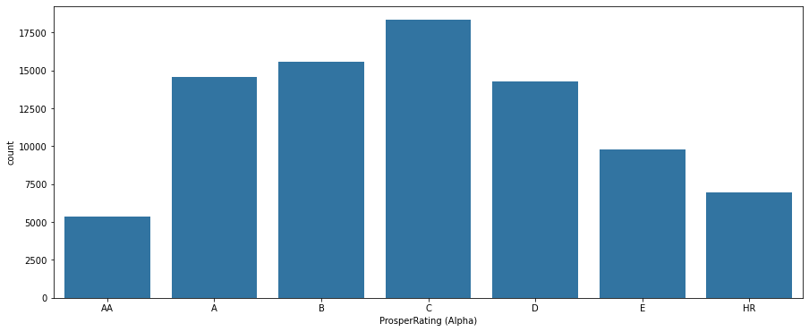

```python
#plotting using countplot to know the ratings that had the highest number of counts
plt.figure(figsize=(15,6))
sns.countplot(prosperloan['ProsperRating (Alpha)'], color = base_color)
```

## Employment Status

Prosper mainly gave to Clients that were Employed which is one of the ways in which they could effectively try to reduce the Risk of Default in the Portfolio

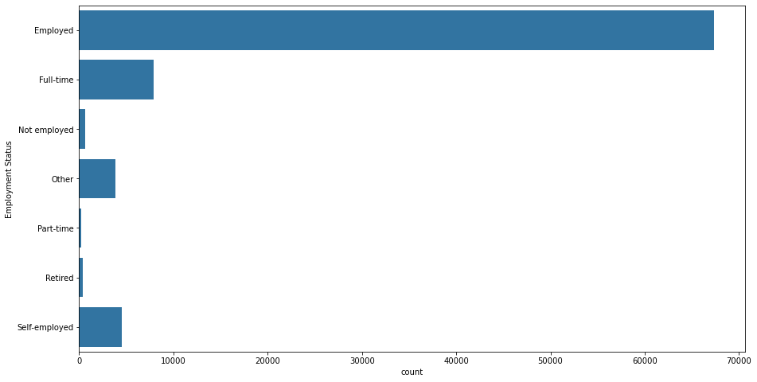

```python
#decided to do a countplot in horizontals
plt.figure(figsize=(15,8))
sns.countplot(data = prosperloan, y='EmploymentStatus', color=base_color)
plt.ylabel('Employment Status')
```

## Debt To Income Ratio

It is a right skewed distribution with most of the customers having relativeliy low debt compared to their income with just few customers breaching the 0.5 ratio mark

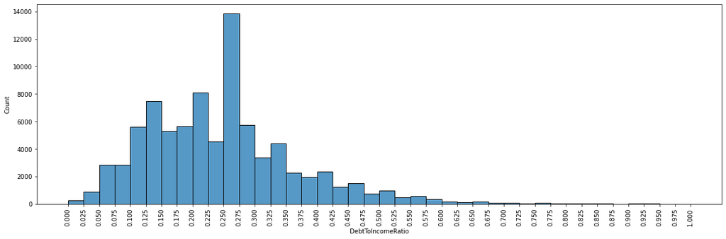

```python
plt.figure(figsize=(20,6))
bin_edges = np.arange(0, 1.0+0.025, 0.025)
sns.histplot(prosperloan.DebtToIncomeRatio, bins = bin_edges)
plt.xticks(ticks=bin_edges, rotation=90)

plt.show()
```

First off, plotting a heatmap would be beneficial to understand the correlation between ome of the Column Variables

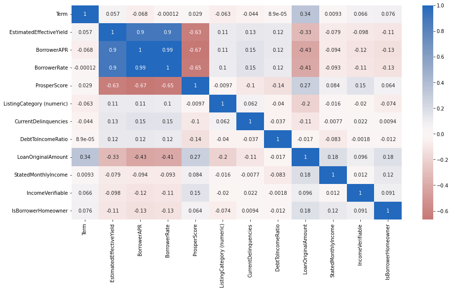

```python
#heatmap using seaborns heatmap
plt.figure(figsize = [15, 8])
sns.heatmap(prosperloan.corr(), annot = True, cmap = 'vlag_r', center = 0)
plt.show()
```

From the heatmap above there is a strong correlation between Effective Yield, Borrower Rate and Borrower APR While opposite is the case between those variables and PosperScore

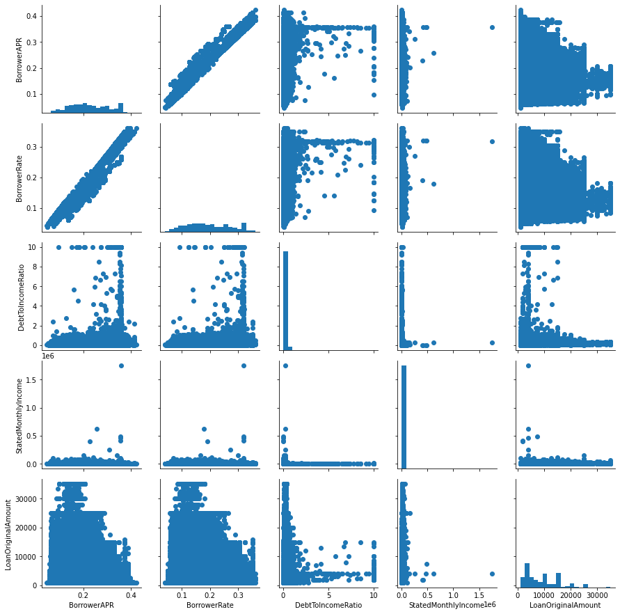

```python
bivars = ['BorrowerAPR', 'BorrowerRate', 'DebtToIncomeRatio', 'StatedMonthlyIncome', 'LoanOriginalAmount']
g = sns.PairGrid(data = prosperloan, vars = bivars)
g = g.map_diag(plt.hist, bins = 20)
g.map_offdiag(plt.scatter);
```

The Pair Grid above confirms a positive correlation between BorrowerAPR nad BorrowerRate

```python
# i used this cell to define a boxplot function that willl be used in a Pair Grid
def boxgrid(x, y, **kwargs):
    default_color = sns.color_palette()[0]
    sns.boxplot(x, y, color = default_color)
    plt.xticks(rotation=90);
```

```python
# i used this cell to define a violinplot function that willl be used in a Pair Grid
def violingrid(x, y, **kwargs):
    default_color = sns.color_palette()[0]
    sns.violinplot(x, y, color = default_color)
    plt.xticks(rotation=90);
```

## Understanding the Relationship between some Quantitave and Qualitative Variables

Through the Pair Grid above: the higher the Rating the lower the APR. It could also be noticed that the higher the loan amount the longer the loan tenor in Term. Higher ProsperScore also resulted in Higher Ratings and vice versa. There was a negative correlation between income Ranges and BorrowerAPr, thereby meaninng that the Higher the customer earns the lower the resulting BorrowerAPR. Customer with higher income also opted for higher loan amounts. Finally it seeems Prosper had a rule that the lower the rating the lower the Loan Amount as that is what it seems throught the information plotted above.

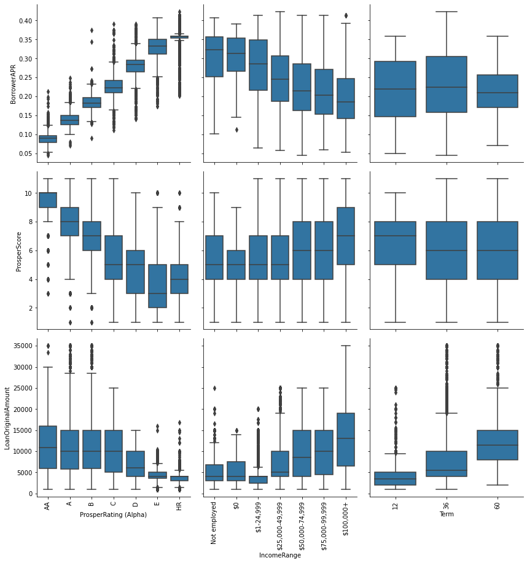

```python
plt.figure(figsize=[20,20])
g = sns.PairGrid(data = prosperloan, x_vars =['ProsperRating (Alpha)', 'IncomeRange', 'Term'], y_vars = ['BorrowerAPR', 'ProsperScore', 'LoanOriginalAmount'], size = 4)
g.map(boxgrid)
plt.show()
```

## Understanding the Realtionship between Borrower APR & Borrower Rate and some other characteristics

Unemployed customers generally had higher Rates than other Employment Statuses signaling that unemployed customers actually pose more risk to Prosper. This could also explain why the lower the Rating the higher the BorrowerRate. This could also be amphaiszed as the Rates became considerably lower with rising income. There was also something very noticeable, the higher the BorrowerRate the more likely for the customer to default or for the loan to be chargedoff

The same things noticed when I examined the Borrower Rate is what was noticed when plotted against the BorrowerAPR. This confirms the earlier findings that both are very closely correlated

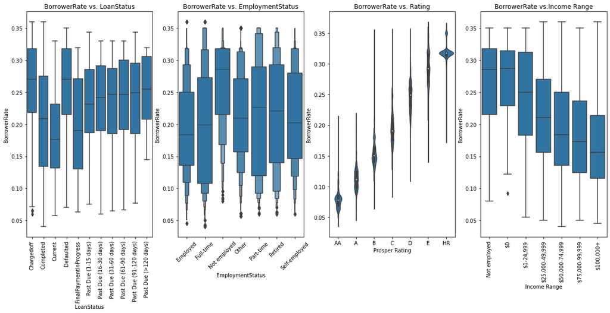

```python
#Using a subplot to achive the plots
plt.figure(figsize = [20,8])

plt.subplot(1,4, 1)
basecolor = sns.color_palette()[0]
sns.boxplot(data = prosperloan, x = 'LoanStatus', y='BorrowerRate', color=basecolor)
plt.xticks(rotation = 90)
plt.title('BorrowerRate vs. LoanStatus')
plt.xlabel('LoanStatus')
plt.ylabel('BorrowerRate')


plt.subplot(1,4,2)
sns.boxenplot(data = prosperloan, x = 'EmploymentStatus', y='BorrowerRate', color=basecolor)
plt.xticks(rotation = 45)
plt.title('BorrowerRate vs. EmploymentStatus')
plt.xlabel('EmploymentStatus')
plt.ylabel('BorrowerRate')


plt.subplot(1,4,3)
sns.violinplot(data = prosperloan, x = 'ProsperRating (Alpha)', y='BorrowerRate', color=basecolor)
plt.title('BorrowerRate vs. Rating')
plt.xlabel('Prosper Rating')
plt.ylabel('BorrowerRate')


plt.subplot(1,4,4)
sns.boxplot(data = prosperloan, x = 'IncomeRange', y='BorrowerRate', color=basecolor)
plt.xticks(rotation = 90)
plt.title('BorrowerRate vs.Income Range')
plt.xlabel('Income Range')
plt.ylabel('BorrowerRate')
```

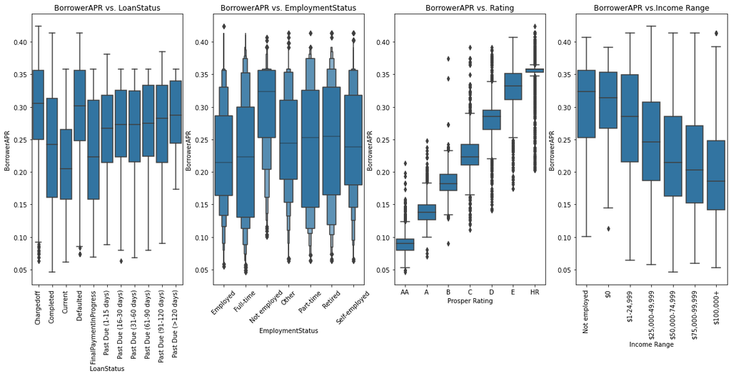

```python
plt.figure(figsize = [20,8])

plt.subplot(1,4, 1)
basecolor = sns.color_palette()[0]
sns.boxplot(data = prosperloan, x = 'LoanStatus', y='BorrowerAPR', color=basecolor)
plt.xticks(rotation = 90)
plt.title('BorrowerAPR vs. LoanStatus')
plt.xlabel('LoanStatus')
plt.ylabel('BorrowerAPR')


plt.subplot(1,4,2)
sns.boxenplot(data = prosperloan, x = 'EmploymentStatus', y='BorrowerAPR', color=basecolor)
plt.xticks(rotation = 45)
plt.title('BorrowerAPR vs. EmploymentStatus')
plt.xlabel('EmploymentStatus')
plt.ylabel('BorrowerAPR')


plt.subplot(1,4,3)
sns.boxplot(data = prosperloan, x = 'ProsperRating (Alpha)', y='BorrowerAPR', color=basecolor)
plt.title('BorrowerAPR vs. Rating')
plt.xlabel('Prosper Rating')
plt.ylabel('BorrowerAPR')


plt.subplot(1,4,4)
sns.boxplot(data = prosperloan, x = 'IncomeRange', y='BorrowerAPR', color=basecolor)
plt.xticks(rotation = 90)
plt.title('BorrowerAPR vs.Income Range')
plt.xlabel('Income Range')
plt.ylabel('BorrowerAPR')
```

## Understanding some Ordinal Variables

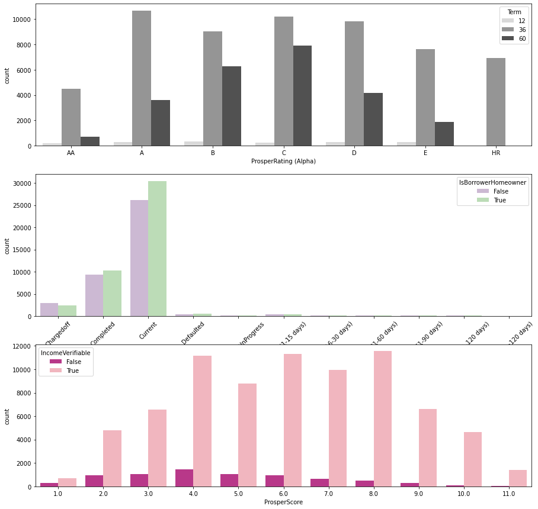

```python
plt.figure(figsize = [15,15])

plt.subplot(3,1,1)
sns.countplot(data=prosperloan, x='ProsperRating (Alpha)', hue='Term', palette ='Greys')
plt.legend(loc = 'upper right', title ='Term')

plt.subplot(3,1,2)
sns.countplot(data=prosperloan, x='LoanStatus', hue='IsBorrowerHomeowner', palette = 'PRGn')
plt.xticks(rotation=45)
plt.legend(loc = 'upper right', title ='IsBorrowerHomeowner')

plt.subplot(3,1,3)
sns.countplot(data=prosperloan, x='ProsperScore', hue='IncomeVerifiable', palette ='RdPu_r')
plt.legend(loc = 'upper left', title ='IncomeVerifiable')


plt.show();
```

The lowest rated loans are seen to medium termed mainly while the higher rated loans were spread between the medium termed and longer termed loans. It is not a coincidence that having a verified source of income leads to a better ProsperScore.

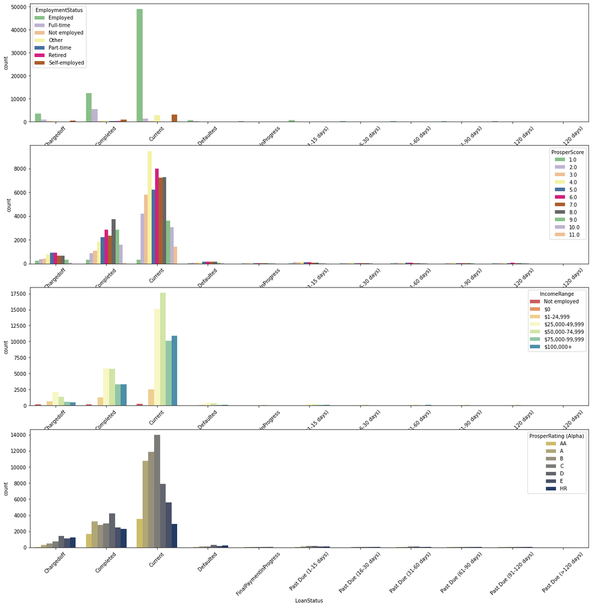

```python
plt.figure(figsize=[20,20])

plt.subplot(4,1,1)
sns.countplot(data=prosperloan, x='LoanStatus', hue='EmploymentStatus', palette='Accent')
plt.xticks(rotation=45)
plt.legend(loc='upper left', title= 'EmploymentStatus')


plt.subplot(4,1,2)
sns.countplot(data=prosperloan, x='LoanStatus', hue='ProsperScore', palette='Accent')
plt.xticks(rotation=45)
plt.legend(loc='upper right', title= 'ProsperScore')


plt.subplot(4,1,3)
sns.countplot(data=prosperloan, x='LoanStatus', hue='IncomeRange', palette='Spectral')
plt.xticks(rotation=45)
plt.legend(loc='upper right', title= 'IncomeRange')


plt.subplot(4,1,4)
sns.countplot(data=prosperloan, x='LoanStatus', hue='ProsperRating (Alpha)', palette='cividis_r')
plt.xticks(rotation=45)
plt.legend(loc='upper right', title= 'ProsperRating (Alpha)')
```

## Comparing Borrower APR & Income Range with Employment Status to understand how Prosper appraised their loans based on IncomeRange and Employment Status to determine APR

Customers that were not employed had a higher BorrowerAPR than the average income earner with common figures of BorrowerAPR above 0.3. Part Time customers had a normally distributed Borrowed APR across the Income Ranges. Higher Income ranges apparently commanded lower Borrower APR.

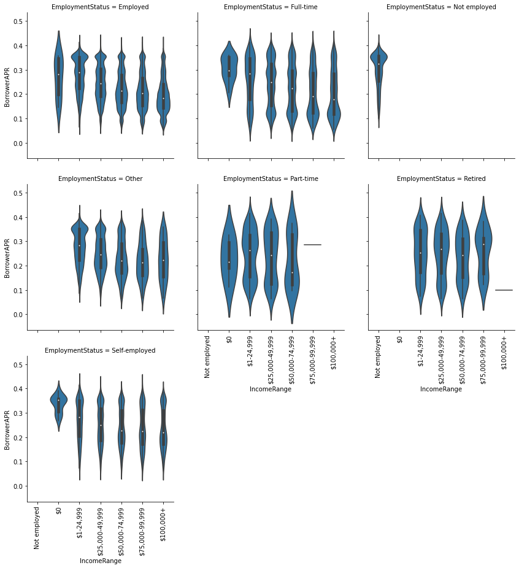

```python
plt.figure(figsize=(20,20))
g = sns.FacetGrid(data = prosperloan, col= 'EmploymentStatus', col_wrap = 3, size =4)
g.map(sns.violinplot, 'IncomeRange', 'BorrowerAPR')
g.set_xlabels('IncomeRange')
g.set_ylabels('BorrowerAPR')

for axes in g.axes.flat:
    _ = axes.set_xticklabels(axes.get_xticklabels(), rotation=90)
```

## Comparing Borrower APR, Income Range and Loan Term to determine the relationship between all three variables

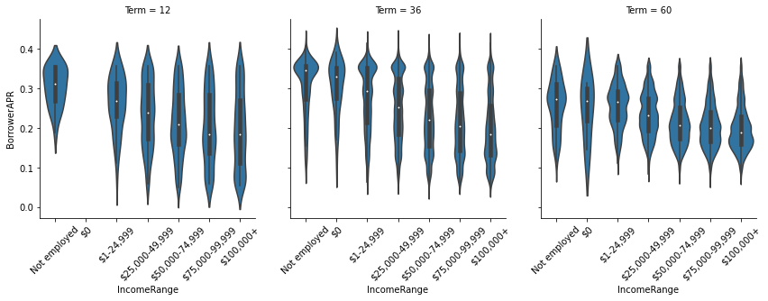

```python
plt.figure(figsize=(20,20))
g = sns.FacetGrid(data = prosperloan, col= 'Term', col_wrap = 3, size =4)
g.map(sns.violinplot, 'IncomeRange', 'BorrowerAPR')
g.set_xlabels('IncomeRange')
g.set_ylabels('BorrowerAPR')

for axes in g.axes.flat:
    _ = axes.set_xticklabels(axes.get_xticklabels(), rotation=45)
```

## Comparing Borrower APR & Income Range with Loan Status To determine the effect of Income and Borrower APR on Loan Status

Most of the ChargedOff loans had a higher BorrowerAPR by their mean irregardless of the Income Range in which they were. For currently running loans Customers not employed had a very high BorrowerAPR indicating that they need to be rechecked and visited so as to prevent defaults that will result in writing off such loans.

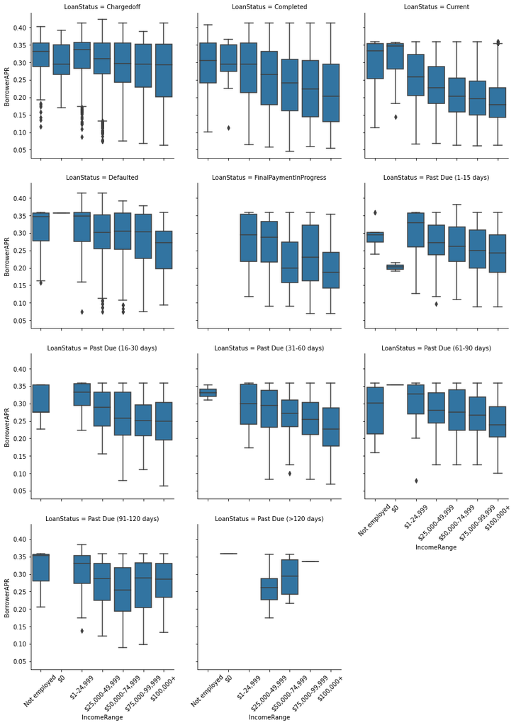

```python
plt.figure(figsize=(20,20))
g = sns.FacetGrid(data = prosperloan, col= 'LoanStatus', col_wrap = 3, size =4)
g.map(sns.boxplot, 'IncomeRange', 'BorrowerAPR')
g.set_xlabels('IncomeRange')
g.set_ylabels('BorrowerAPR')

for axes in g.axes.flat:
    _ = axes.set_xticklabels(axes.get_xticklabels(), rotation=45)


plt.show()
```

```python
!jupyter nbconvert Prosper_Loan_Analysis_Part_2_(Slides_Presentation) --to slides --no-input
```

```
[NbConvertApp] Converting notebook Prosper_Loan_Analysis_Part_2_(Slides_Presentation).ipynb to slides
[NbConvertApp] Writing 1205746 bytes to Prosper_Loan_Analysis_Part_2_(Slides_Presentation).slides.html
```